# startR 4: Graphiques de base

Lise Vaudor

21 mars 2017

# Graphiques: Plot()

On peut tracer un nuage de points à l’aide de la fonction **plot()**.

Pour tracer les valeurs d’une variable **x** (Temp):

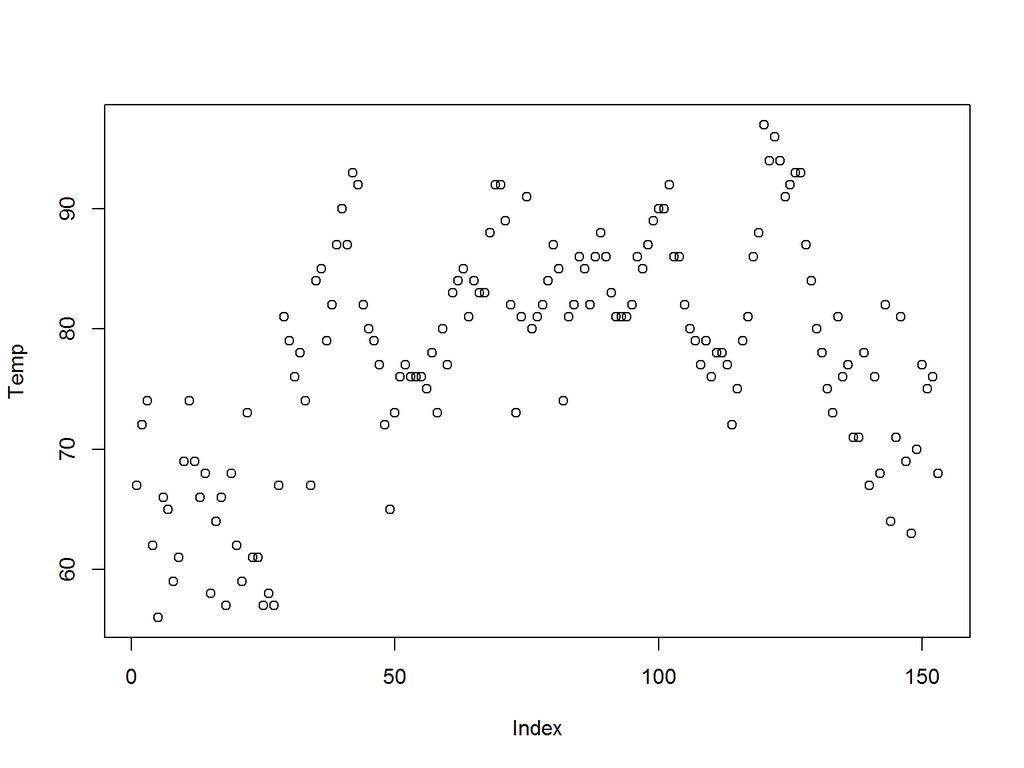

```r
plot(Temp)
```

Pour tracer une variable **y** (Ozone) en fonction d’une variable **x** (Temp)

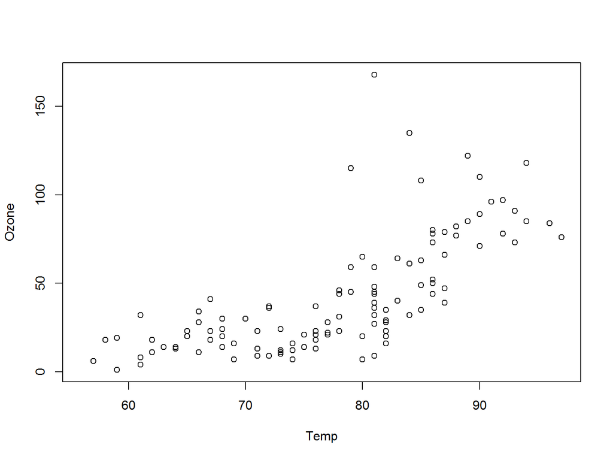

```r
plot(Temp,Ozone)
```

# Graphiques: Plot()

La fonction plot() a de nombreux arguments, permettant entre autres de modifier

- le **type** de graphique (**type**) (par exemple, est-ce que les points doivent être reliés les uns aux autres par une ligne?)
- la **couleur** (**col**),
- le **symbole** (**pch**),
- le **titre** principal (**main**),
- les **étiquettes** des axes (**xlab**,**ylab**)
- la **largeur des lignes** (**lwd**)
- le **type de lignes** (**lty**)
- la **taille des symboles** (**cex**)

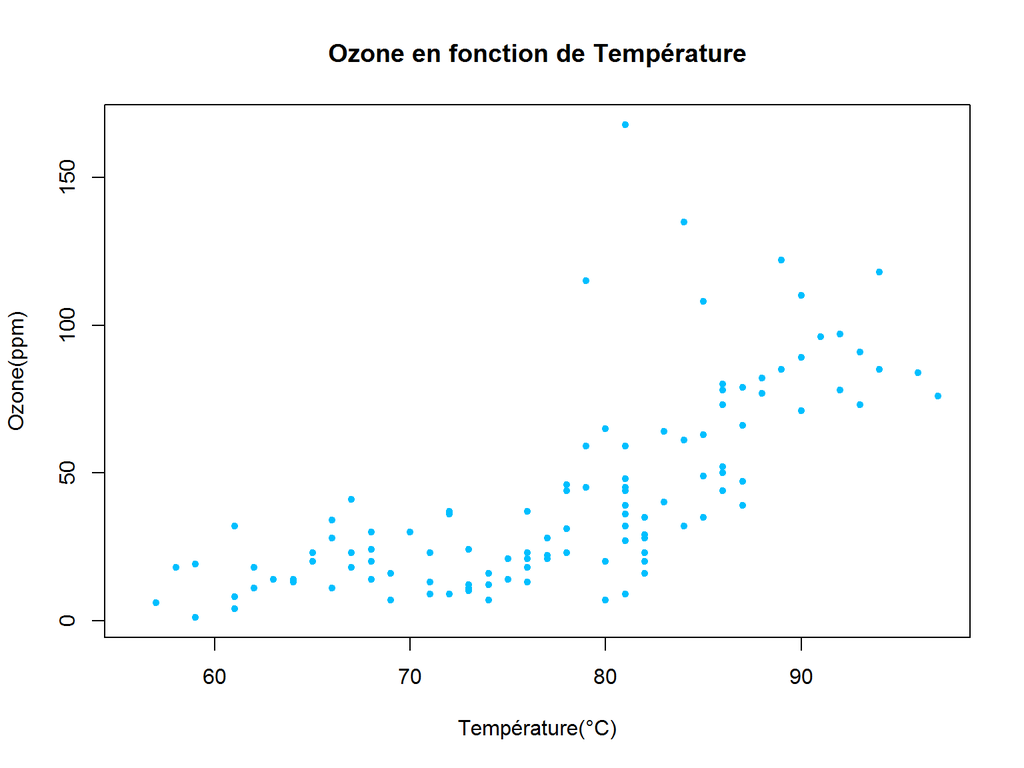

```r
plot(Temp,
     Ozone,
     col="deepskyblue",
     pch=20,
     main="Ozone en fonction de Température",
     xlab="Température(°C)",
     ylab="Ozone(ppm)")
```

# Graphiques: Plot()

La fonction plot() a de nombreux arguments, permettant entre autres de modifier

- le **type** de graphique (**type**) (par exemple, est-ce que les points doivent être reliés les uns aux autres par une ligne?)
- la **couleur** (**col**),
- le **symbole** (**pch**),
- le **titre** principal (**main**),
- les **étiquettes** des axes (**xlab**,**ylab**)
- la **largeur des lignes** (**lwd**)
- le **type de lignes** (**lty**)
- la **taille des symboles** (**cex**)

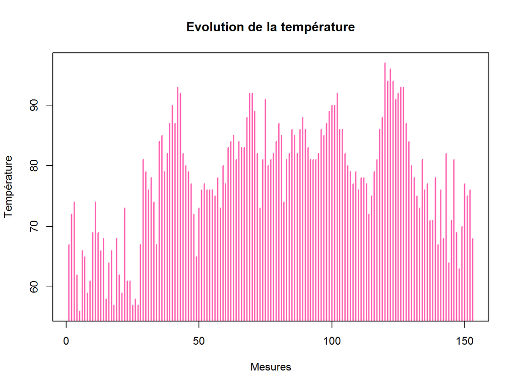

```r
plot(Temp,
     type="h",
     col="hotpink",
     lwd=2,
     main="Evolution de la température",
     xlab="Mesures",
     ylab="Température")
```

# Graphiques: Plot()

La fonction plot() a de nombreux arguments, permettant entre autres de modifier

- le **type** de graphique (**type**) (par exemple, est-ce que les points doivent être reliés les uns aux autres par une ligne?)
- la **couleur** (**col**),
- le **symbole** (**pch**),
- le **titre** principal (**main**),
- les **étiquettes** des axes (**xlab**,**ylab**)
- la **largeur des lignes** (**lwd**)
- le **type de lignes** (**lty**)
- la **taille des symboles** (**cex**)

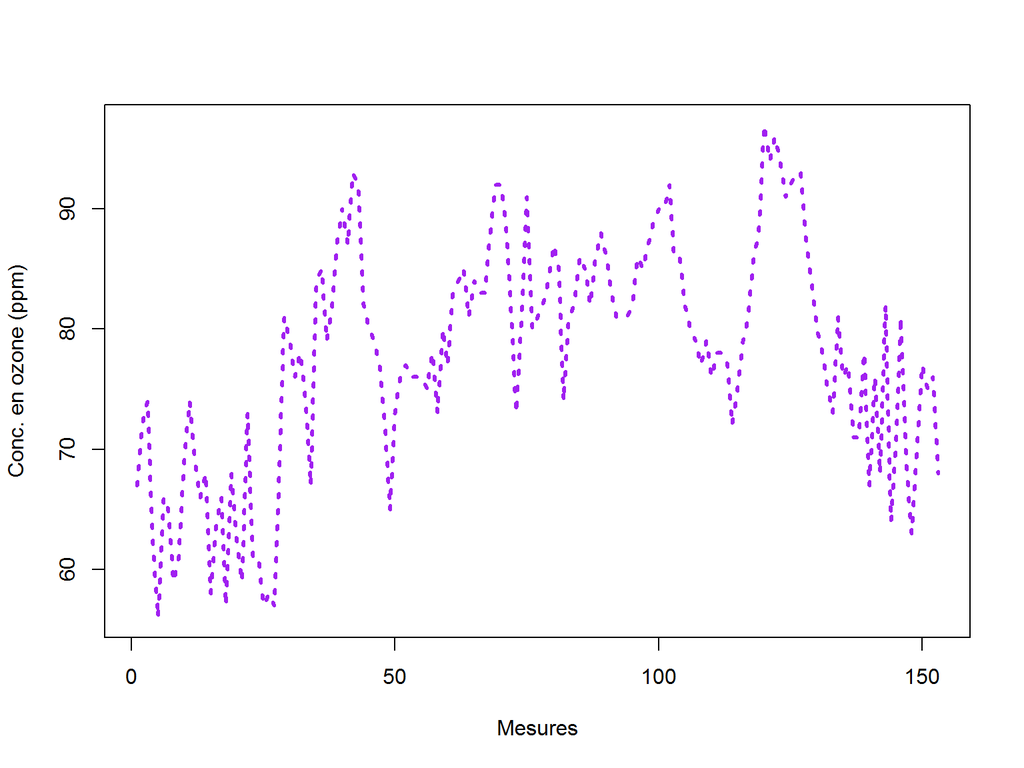

```r
plot(Temp,
     type="l",
     col="purple",
     lwd=3,
     lty=3,
     xlab="Mesures",
     ylab="Conc. en ozone (ppm)")
```

# Graphiques: Superposer plusieurs graphes

On peut superposer plusieurs graphiques, par exemple en appelant d’abord une fonction graphique “de base” puis en appelant une des fonctions suivantes:

- `points()`pour superposer un nuage de points
- `abline()`pour rajouter une ligne, de pente “a” et d’ordonnée à l’origine “b” ou une ligne verticale d’abscisse “v” ou une ligne horizontale d’ordonnée “h”
- `text()` pour rajouter du texte

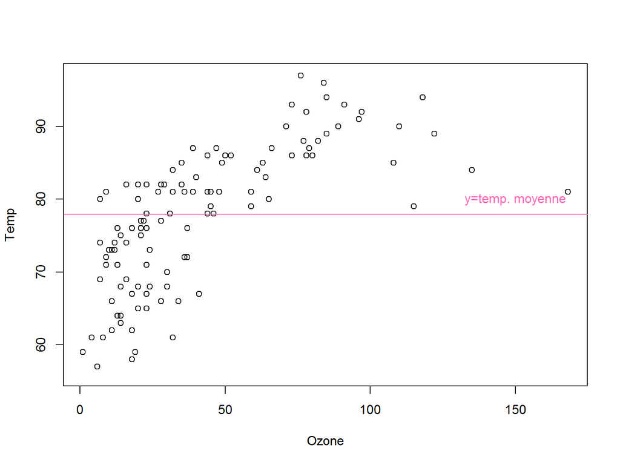

```r
plot(Ozone,Temp)
abline(h=mean(Temp),
       col="hotpink")
text(150,
     80,
     labels="y=temp. moyenne",
     col="hotpink")
```

# Graphiques: Boîtes à moustaches

Les **boîtes à moustaches** (ou **boxplots**, en anglais) sont un moyen extrêmement classique de représenter les distributions.

La “boîte” est délimitée par les **1er et 3ème quartiles**. Une barre horizontale marque la **médiane**.

Soit $H$ la hauteur de la boîte. Les moustaches s’étendent:

- soit jusqu’aux **extrema** si ceux-ci s’éloignent de la boîte de **moins de $\tau=1.5H$**
- soit jusqu’à **$\tau=1.5H$**, les valeurs situées au-delà étant alors décrites comme **outliers**

On peut **modifier la valeur de $\tau$** (argument **range**) de la fonction boxplot():

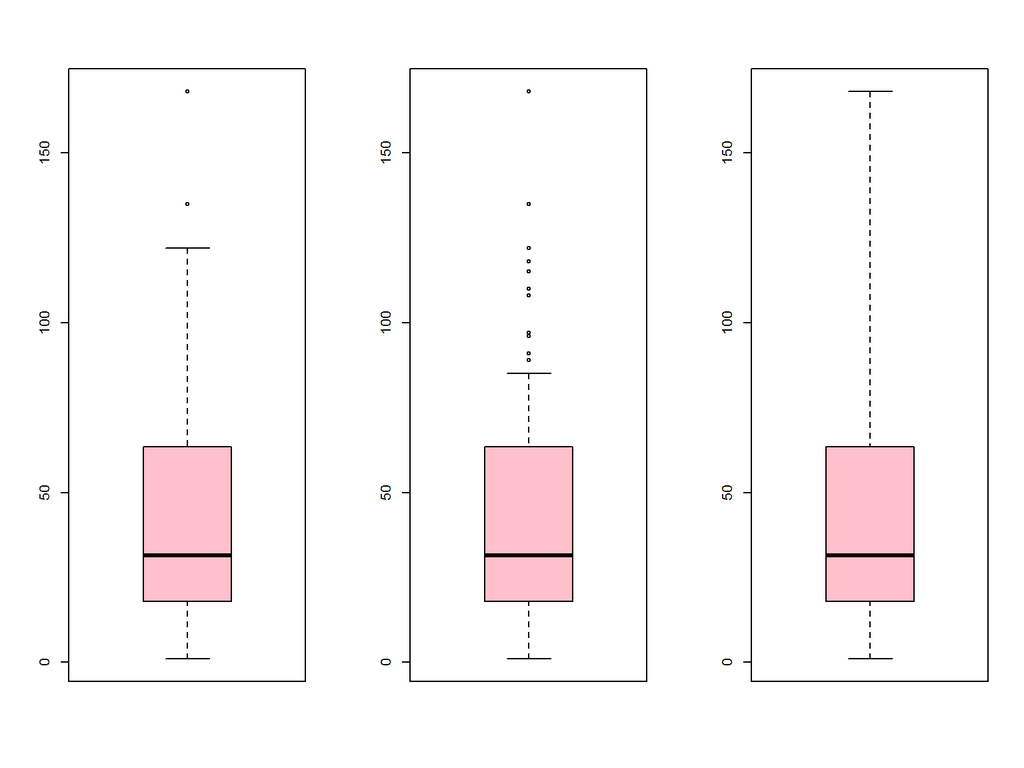

```r
layout(matrix(1:3,nrow=1))
boxplot(Ozone, col="pink")
# pour que les moustaches soient plus courtes:
boxplot(Ozone, col="pink", range=0.5)
# pour que les moustaches s'étendent jusqu'aux extrêmes:
boxplot(Ozone, col="pink", range=0)
```

# Graphiques: Boîtes à moustaches

Le plus souvent, les boîtes à moustaches sont utilisées pour représenter simultanément les distributions des observations pour **plusieurs groupes**, par exemple:

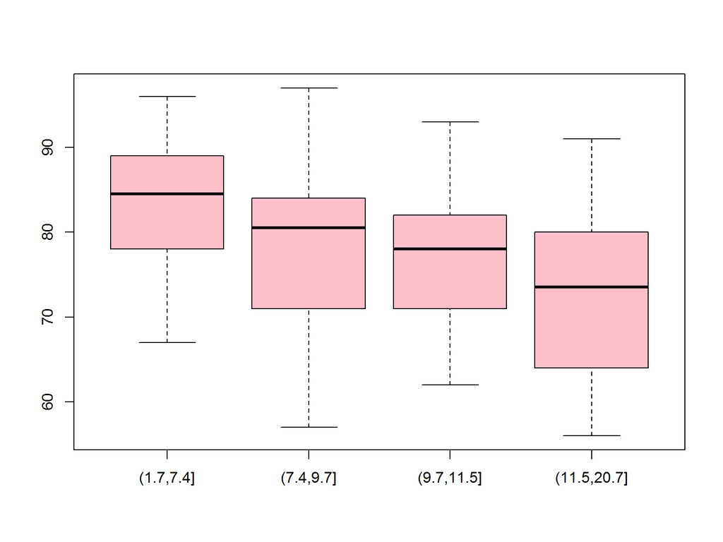

```r
boxplot(Temp~gWind, col="pink")
```

```r
resume <- summarise(group_by(air,gWind),mTemp=mean(Temp))
resume
```

```
## # A tibble: 5 × 2
##         gWind    mTemp
##        <fctr>    <dbl>
## 1   (1.7,7.4] 83.85714
## 2   (7.4,9.7] 77.55263
## 3  (9.7,11.5] 77.41176
## 4 (11.5,20.7] 72.07895
## 5          NA 76.00000
```

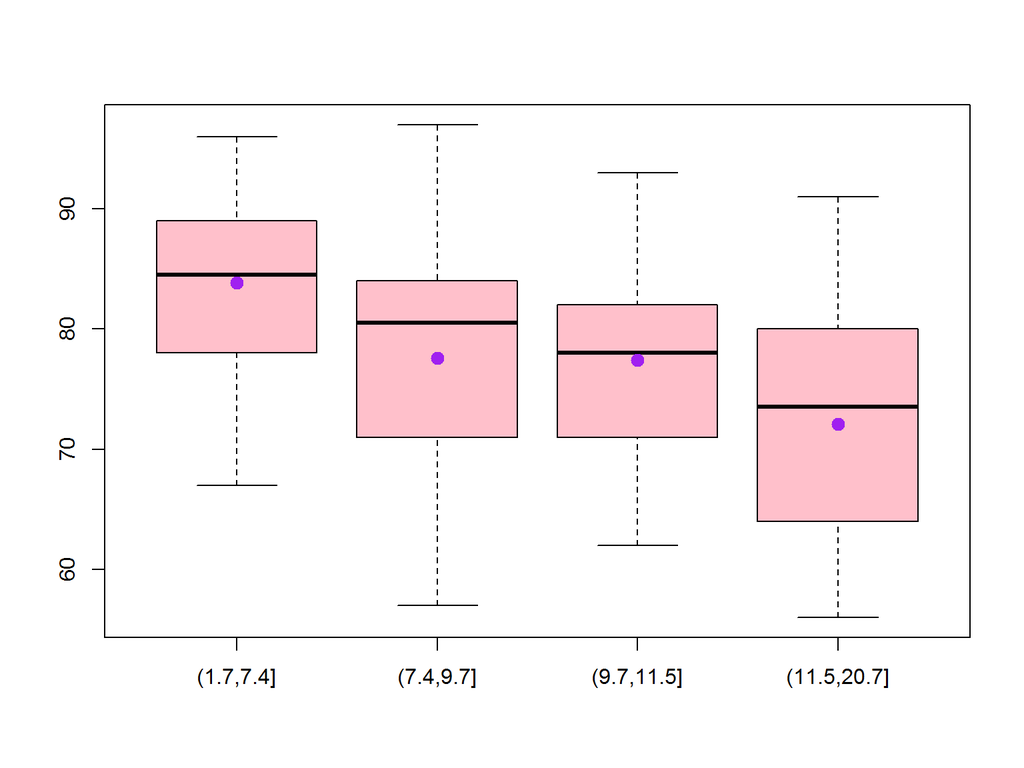

```r
boxplot(Temp~gWind, col="pink")
points(resume$gWind,resume$mTemp,
       cex=2,pch=20,col="purple")
```

# Graphiques: Histogrammes

Les **histogrammes** offrent un mode de **représentation des distributions** plus précis que les boîtes à moustaches.

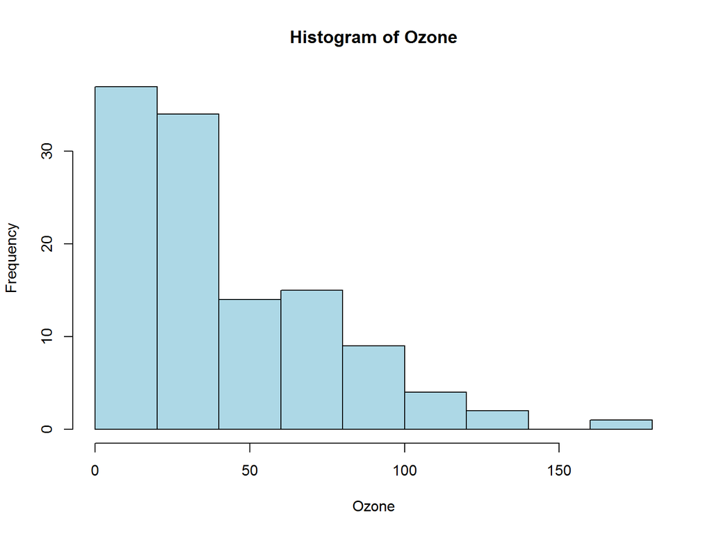

```r
hist(Ozone, col="light blue")
```

L’argument **breaks** permet de spécifier comment former les classes pour le tracé de l’histogramme:

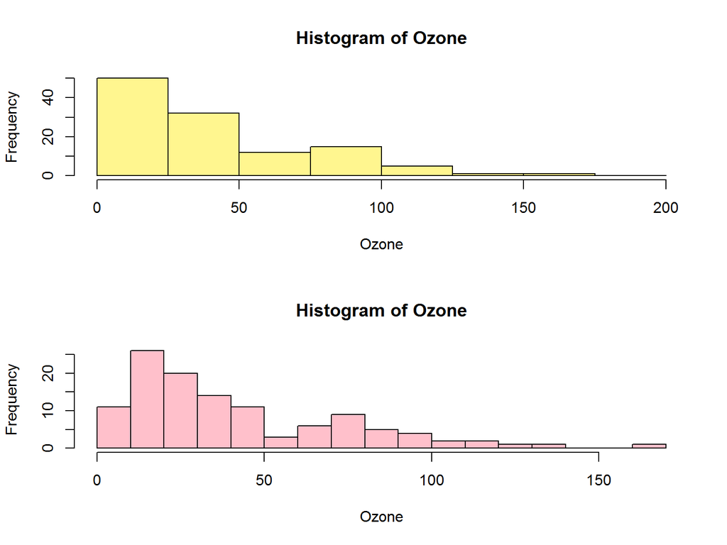

```r
layout(matrix(1:2,nrow=2))
hist(Ozone, col="khaki1", breaks=seq(0,200,25))
hist(Ozone, col="pink", breaks=20)
```

# Rapports

[figure not shown]

[figure not shown]

# Rapports : Tricoter un .Rmd en .docx, .html, .pdf

[figure not shown]

# Rapports : Tricoter un .Rmd en .docx, .html, .pdf

[figure not shown]

# Rapports: Premier niveau de titre

[figure not shown]

# Rapports: Premier niveau de titre

[figure not shown]

# Rapports: Deuxième niveau de titre

[figure not shown]

# Rapports: Deuxième niveau de titre

[figure not shown]

# Rapports : Chunks de code

[figure not shown]

# Rapports : Chunks de code

[figure not shown]

# Rapports : Chunks de code muets

[figure not shown]

# Rapports : Chunks de code muets

[figure not shown]

# Rapports : Chunks de code incrustés

[figure not shown]

# Rapports : Chunks de code incrustés

[figure not shown]

# Rapports: Chunks graphiques

[figure not shown]

# Rapports: Chunks graphiques

[figure not shown]